# **O que é um Jupyter Notebook?**

O jupyter notebook e JupyterLab são uma aplicações tanto para **desenvolver e executar** códigos quanto elementos de texto, figuras, links, vídeos, equações, etc. Como podemos misturar texto e código em um mesmo lugar, estes documentos ficam ideais para gerar e descrever análises onde tanto a formulação da ideia, a visualização do resultado e a descrição do resultado pode ser feita num mesmo lugar.

- [Documentação do Jupyter](https://jupyter.org/documentation)
- [Documentação do IPython API](https://ipython.readthedocs.io/en/stable/api/index.html)
- [Site oficial do Jupyter](http://jupyter.org/)

## **Células**

Isso é uma célula de texto. Células de texto aceitam marcação conhecida como Markdown. Em uma célula de código nós podemos usar o Python como usamos em um script qualquer:

```python
# isso é uma célula de código

for count in range(0,5):
    print(count)
print('end')
```

```
0
1
2
3
4
end
```

Cada célula é um ambiente **isolado** que pode ser rodado separadamente. Você pode rodar cada célula individualmente e na sequência que desejar, mas as variáveis que ela usa precisam estar referenciadas antes do seu uso.

**OBS:** caso haja dependencia entre celulas, garanta que todas as celulas foram executadas (*run all cells*)

```python
import this
```

```
The Zen of Python, by Tim Peters

Beautiful is better than ugly.
Explicit is better than implicit.
Simple is better than complex.
Complex is better than complicated.
Flat is better than nested.
Sparse is better than dense.
Readability counts.
Special cases aren't special enough to break the rules.
Although practicality beats purity.
Errors should never pass silently.
Unless explicitly silenced.
In the face of ambiguity, refuse the temptation to guess.
There should be one-- and preferably only one --obvious way to do it.
Although that way may not be obvious at first unless you're Dutch.
Now is better than never.
Although never is often better than *right* now.
If the implementation is hard to explain, it's a bad idea.
If the implementation is easy to explain, it may be a good idea.
Namespaces are one honking great idea -- let's do more of those!
```

## **Teclas de atalho**

- **Tab** = code completion or indent
- **Shift + Tab** = tooltip
- **Ctrl + Enter** = run cell
- **Y** = code
- **M** = markdown

## **Fórmulas matemáticas**

Também é possível usar fórmulas junto com o texto. Isso é muito útil quando se tem uma explicação matemática necessária para entender o código. A escrita é feita da mesma forma que no LaTeX:

$$c = \sqrt{a^2 + b^2}$$

## **Visualização**

```python
import matplotlib.pyplot as plt

plt.plot(range(0,100))
```

[output not shown]

### Visualize imagens em diretórios:

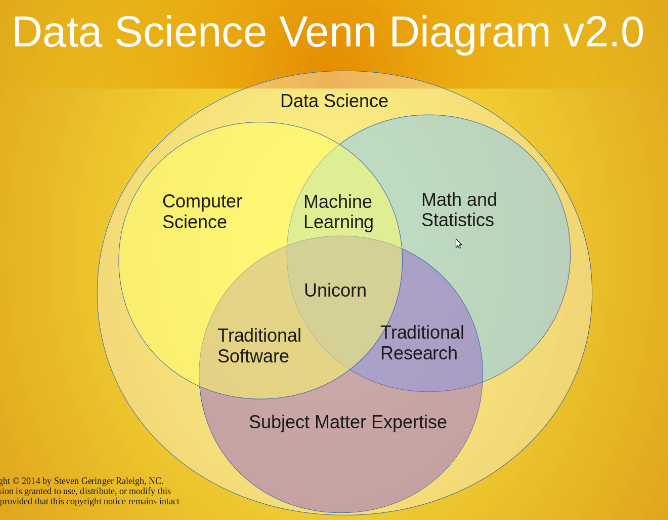

```python
from IPython.core.display import Image

Image('/home/brunocampos01/Imagens/Seleção_048.png')
```

### Visualize imagens na web:

```python
from IPython.display import HTML
from IPython.display import IFrame

HTML('<iframe width="400" height="250" src="https://prod-discovery.edx-cdn.org/media/course/image/8f8e5124-1dab-47e6-8fa6-3fbdc0738f0a-3e63dd548729.small.jpg" allowfullscreen></iframe>')
```

[interactive chart not shown]

## **Vídeos**

Também podemos inserir vídeos do youtube como parte da sequência lógica da explicação:

```python
from IPython.display import YouTubeVideo

YouTubeVideo('vfWv7j4FIxQ', width=800, height=600)
```

[video not shown]

```python
#Outra forma de inserir video, com a biblioteca HTML

HTML('<iframe width="560" height="315" src="https://www.youtube.com/embed/yRsBuMYSbSY" frameborder="0" allow="autoplay; encrypted-media" allowfullscreen></iframe>')
```

[video not shown]

## **Sites**

Para inserir um site é necessário a biblioteca importar a *IFrame*

```python
#editor de markdown

IFrame('https://stackedit.io/app#', width=900, height=550)
```

[interactive chart not shown]

## **Terminal**

É possível executar comandos do terminal UNIX. Para isso é necessário começar com (!)

```python
!ls ./
```

```
jupyter_notebook.ipynb	output_2_0.png	performace_python_and_pandas.ipynb
notebook.tex		papirus
```

### Fontes:

- https://courses.edx.org/courses/course-v1:UCSanDiegoX+DSE200x+1T2018/courseware/cab57e3b8e31453bab5de3226e82dbb6/efc947a249af4af29298f43dbe2a47b1/1?activate_block_id=block-v1%3AUCSanDiegoX%2BDSE200x%2B1T2018%2Btype%40vertical%2Bblock%4030b07978a4c245ff95f7bc8aae7f6247
- https://github.com/leportella/tutorial-modulos-data-science/blob/master/1-Jupyter.ipynb
- http://jupyter.org/
- https://stackedit.io/app#